# FIN3380: HW2

Due: Sep 30, 2019 (Monday of Week 5)

## Q1: Work on the “dj.csv” index data which contains DJ index daily data.

- 1. Subset your data to dates between 1985-01-01 and 2007-12-31.
- 2. Construct a 7 day RSI for your DJ data
- 3. How many days in total that the RSI is above or equal 70? How many days in total that the RSI is below or equal 30?
- 4. Check the performance of the following strategy: Buy the dji index at the close price when the rsi rises from below the oversold line (line 30), sell it at the close price on the following day. That is buy the stock if yesterday’s RSI < 30 but today’s RSI >=30.

```r
library(dplyr)
library(zoo)
dj=read.csv("dj.csv")
dj$date = as.character(dj$date)
dj = dj %>% filter (date>='1985-01-01' &(date<='2007-12-31'))
dj = dj %>% mutate(delta=dji-lag(dji,1)) %>%
  mutate(up.val = ifelse(delta>=0,delta,0),
         down.val = ifelse(delta<0,-delta,0))
dj = dj[2:nrow(dj),]
dj = dj %>% arrange(date) %>%
  mutate(up.first.avg=rollapply(up.val,width=7,align='right',fill=NA,
                                FUN=mean,na.rm=T),
         down.first.avg=rollapply(down.val,width=7,align='right',fill=NA,
                                FUN=mean,na.rm=T))
dj$up.avg = dj$up.first.avg
dj$down.avg = dj$down.first.avg

for (t in 8:length(dj$up.avg)){
  dj$up.avg[t] = dj$up.avg[t-1]*6/7 + dj$up.val[t]*1/7
  dj$down.avg[t] = dj$down.avg[t-1]*6/7 + dj$down.val[t]*1/7
}

dj$rs = dj$up.avg/dj$down.avg
dj$rsi = 100-100/(1+dj$rs)

cat("n days RSI>=70: ",length(which(dj$rsi>=70)),"\n")
```

```
## n days RSI>=70:  1168
```

```r
cat("n days RSI<=30: ",length(which(dj$rsi<=30)))
```

```
## n days RSI<=30:  466
```

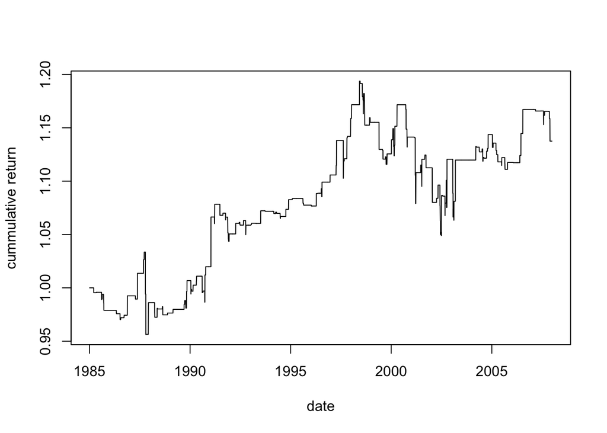

```r
dj = dj %>% mutate(lag.rsi=lag(rsi,1)) %>%
  mutate(buy.flag=ifelse(((lag.rsi<30)&(rsi>=30)),1,0))
dj = dj %>% mutate(buy.flag=ifelse(is.na(buy.flag),0,buy.flag))
dj = dj %>% arrange(date) %>%
  mutate(ret.lead=lead(dji,1)/dji-1) %>%
  mutate(ret.strat=ret.lead*buy.flag) %>%
  mutate(ret.cum=cumprod(ret.strat+1))
plot(dj$ret.cum~as.Date(dj$date),type='l',
     xlab='date',ylab='cummulative return')
```

## Q2: Work on crsp.sample.RData:

1. Calculate your Equal-weighted index return over the entire periods, however, rather than reallocate monthly, reallocate your portfolio at the begining of each quarter, that is, the reallocation dates are the first trading date after 01-01, 04-01, 07-01, 10-01 each year. (Hint: use function as.yearqtr from the library(zoo)). Plot your index cumulative return on first quarter of 2012. Plot your cumulative index performance over the entire trading periods.
2. Repeat a. to construct Value-weighted index with quarterly reallocation
3. equal weighted

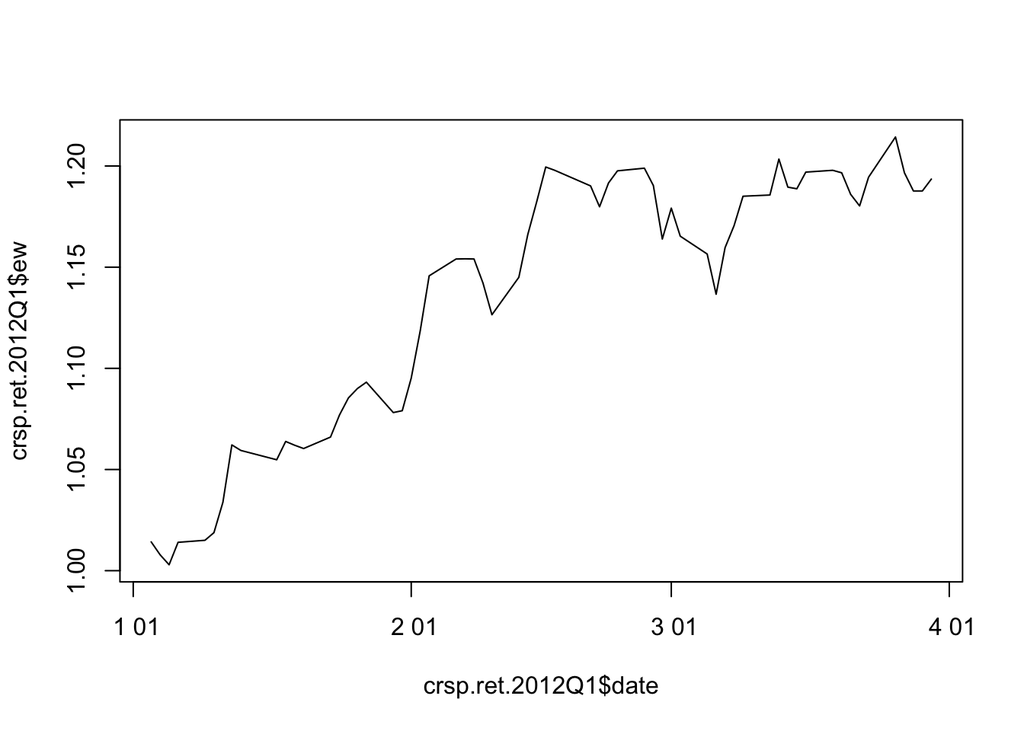

```r
library(dplyr)
library(zoo)
library(tidyr)
load("crsp.sample.RData")
crsp.ret = spread(crsp.sample[,c("permno","date","ret")],permno,ret)
crsp.ret = gather(crsp.ret,key=permno,value=ret,-date)
crsp.ret = crsp.ret %>%
  mutate(ret=ifelse(is.na(ret),0,ret))

crsp.ret$yysea = as.yearqtr(crsp.ret$date, format = "%Y-%m-%d")
crsp.ret = crsp.ret %>% group_by(permno,yysea) %>%
  mutate(cumret=cumprod(ret+1))
crsp.ew = crsp.ret %>% group_by(date) %>%
  summarise(ew=mean(cumret),
  yysea=first(yysea))
crsp.ew = crsp.ew %>% filter(yysea!=first(yysea))


crsp.ret.2012Q1 = crsp.ew %>% filter(yysea=='2012 Q1')
plot(crsp.ret.2012Q1$ew~crsp.ret.2012Q1$date,type='l')
```

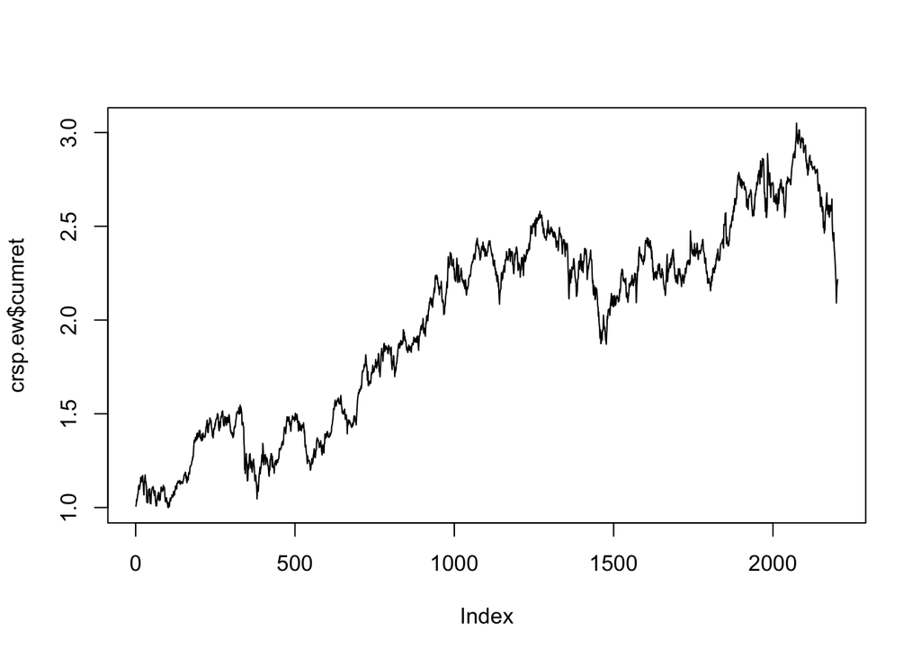

```r
crsp.ew = crsp.ew %>% group_by(yysea) %>%
  arrange(date) %>%
  mutate(ret=ew/lag(ew,1)-1,
         ret=ifelse(is.na(ret),ew-1,ret)) %>% ungroup() %>%
  mutate(cumret=cumprod(ret+1))
plot(crsp.ew$cumret,type='l')
```

2. value weighted

```r
crsp.sample = crsp.sample %>%
  mutate(me=abs(prc)*shrout) %>%
  select(permno,date,ret,me) %>%
  mutate(permno=as.character(permno))

# handling missing returns
crsp.ret = spread(crsp.sample[,c("permno","date","ret")],permno,ret)
crsp.ret = gather(crsp.ret,key=permno,value=ret,-date)
crsp.ret = crsp.ret %>%
  mutate(ret=ifelse(is.na(ret),0,ret))

# seperate market cap into another dataframe and merge back onto returns
crsp.me = crsp.sample %>% select(permno,date,me)
crsp.sample = crsp.ret %>% left_join(crsp.me,by=c("permno","date"))
head(crsp.sample)
```

```
##         date permno          ret      me
## 1 2010-01-04  11600  0.004549436 5193510
## 2 2010-01-05  11600 -0.011887969 5131770
## 3 2010-01-06  11600  0.006588357 5165580
## 4 2010-01-07  11600  0.013090469 5233200
## 5 2010-01-08  11600  0.000000000 5233200
## 6 2010-01-11  11600  0.012921430 5300820
```

```r
# lag me(get lag returns)
crsp.vw = crsp.sample %>%
  group_by(permno) %>%
  arrange(date) %>%
  mutate(lag.me=lag(me,1)) %>% ungroup()

# keep the first value of lag.me for each quarter which is the last date me from last quarter
crsp.vw = crsp.vw %>%
  mutate(yysea=as.yearqtr(crsp.vw$date, format = "%Y-%m-%d")) %>%
  group_by(permno,yysea) %>%
  arrange(date) %>%
  mutate(lag.me=first(lag.me)) %>% ungroup()
head(crsp.vw)
```

```
## # A tibble: 6 x 6
##   date       permno     ret       me lag.me yysea
##   <date>     <chr>    <dbl>    <dbl>  <dbl> <S3: yearqtr>
## 1 2010-01-04 11600  0.00455 5193510.     NA 2010 Q1
## 2 2010-01-04 13610  0.0354  1424607.     NA 2010 Q1
## 3 2010-01-04 39731  0.0724     9377.     NA 2010 Q1
## 4 2010-01-04 79089  0.00417 2254530.     NA 2010 Q1
## 5 2010-01-04 83148  0.0224   168190.     NA 2010 Q1
## 6 2010-01-04 85459  0.0104  9915595.     NA 2010 Q1
```

```r
# remove the first quarter
crsp.vw = crsp.vw %>% filter(yysea!=first(yysea))
head(crsp.vw)
```

```
## # A tibble: 6 x 6
##   date       permno      ret       me   lag.me yysea
##   <date>     <chr>     <dbl>    <dbl>    <dbl> <S3: yearqtr>
## 1 2010-04-01 11600  -0.0115  5044424. 5102944. 2010 Q2
## 2 2010-04-01 13610   0.00408 1552340. 1546036. 2010 Q2
## 3 2010-04-01 39731   0.0468    14152.   13520. 2010 Q2
## 4 2010-04-01 79089   0.0284  2614824. 2542997. 2010 Q2
## 5 2010-04-01 83148  -0.0302   169829.  175112. 2010 Q2
## 6 2010-04-01 85459  -0.00304 9251009. 9279254. 2010 Q2
```

```r
# fill NA with 0
crsp.vw = crsp.vw %>% mutate(lag.me=ifelse(is.na(lag.me),0,lag.me))

# calculate the weight
crsp.vw = crsp.vw %>%
  group_by(date) %>%
  mutate(wgt=lag.me/sum(lag.me,na.rm=T)) %>%
  ungroup()
head(crsp.vw)
```

```
## # A tibble: 6 x 7
##   date       permno      ret       me   lag.me yysea              wgt
##   <date>     <chr>     <dbl>    <dbl>    <dbl> <S3: yearqtr>    <dbl>
## 1 2010-04-01 11600  -0.0115  5044424. 5102944. 2010 Q2       0.212
## 2 2010-04-01 13610   0.00408 1552340. 1546036. 2010 Q2       0.0642
## 3 2010-04-01 39731   0.0468    14152.   13520. 2010 Q2       0.000561
## 4 2010-04-01 79089   0.0284  2614824. 2542997. 2010 Q2       0.106
## 5 2010-04-01 83148  -0.0302   169829.  175112. 2010 Q2       0.00727
## 6 2010-04-01 85459  -0.00304 9251009. 9279254. 2010 Q2       0.385
```

```r
# calculate the cumulative returns of each individual stock over each quarter
crsp.vw = crsp.vw %>%
  group_by(yysea,permno) %>%
  arrange(date) %>%
  mutate(cumret=cumprod(ret+1)) %>% ungroup()
crsp.vw = crsp.vw %>% arrange(date,permno)
head(crsp.vw)
```

```
## # A tibble: 6 x 8
##   date       permno      ret       me   lag.me yysea             wgt cumret
##   <date>     <chr>     <dbl>    <dbl>    <dbl> <S3: yearqtr>   <dbl>  <dbl>
## 1 2010-04-01 11600  -0.0115  5044424. 5102944. 2010 Q2       2.12e-1  0.989
## 2 2010-04-01 13610   0.00408 1552340. 1546036. 2010 Q2       6.42e-2  1.00
## 3 2010-04-01 39731   0.0468    14152.   13520. 2010 Q2       5.61e-4  1.05
## 4 2010-04-01 79089   0.0284  2614824. 2542997. 2010 Q2       1.06e-1  1.03
## 5 2010-04-01 83148  -0.0302   169829.  175112. 2010 Q2       7.27e-3  0.970
## 6 2010-04-01 85459  -0.00304 9251009. 9279254. 2010 Q2       3.85e-1  0.997
```

```r
# get value weighted index
crsp.vw = crsp.vw %>%
  mutate(vw=wgt*cumret)

crsp.vw = crsp.vw %>%
  group_by(date) %>%
  summarise(vw=sum(vw),
            yysea=first(yysea)) %>%
  ungroup()
head(crsp.vw)
```

```
## # A tibble: 6 x 3
##   date          vw yysea
##   <date>     <dbl> <S3: yearqtr>
## 1 2010-04-01  1.00 2010 Q2
## 2 2010-04-05  1.01 2010 Q2
## 3 2010-04-06  1.02 2010 Q2
## 4 2010-04-07  1.01 2010 Q2
## 5 2010-04-08  1.01 2010 Q2
## 6 2010-04-09  1.02 2010 Q2
```

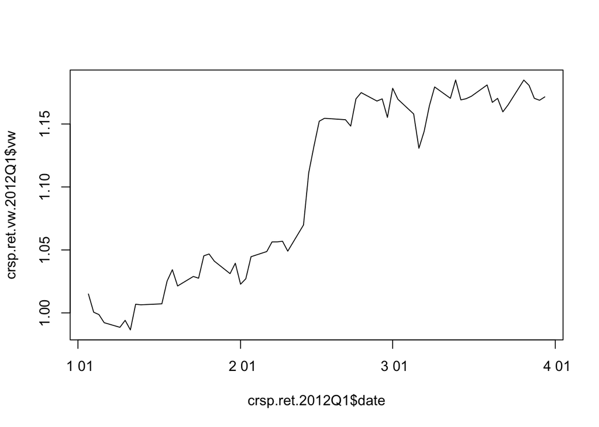

```r
# make plot of the vw index
crsp.ret.vw.2012Q1 = crsp.vw %>% filter(yysea=='2012 Q1')
plot(crsp.ret.vw.2012Q1$vw~crsp.ret.2012Q1$date,type='l')
```

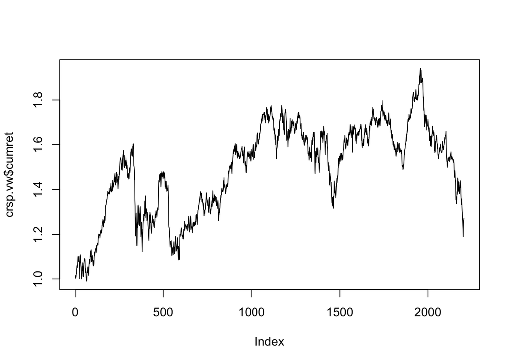

```r
crsp.vw = crsp.vw %>% group_by(yysea) %>%
  arrange(date) %>%
  mutate(ret=vw/lag(vw,1)-1,
         ret=ifelse(is.na(ret),vw-1,ret)) %>% ungroup() %>%
  mutate(cumret=cumprod(ret+1))
plot(crsp.vw$cumret,type='l')
```

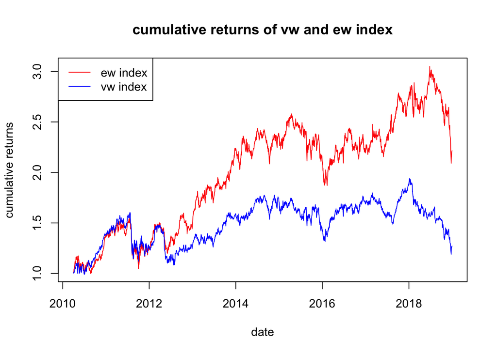

```r
# compare the cumulative return of ew and vw index
plot(crsp.ew$cumret~ as.Date(crsp.ew$date),type='l',ylab='cumulative returns',
     main='cumulative returns of vw and ew index', col='red',xlab='date')
lines (crsp.vw$cumret~ as.Date(crsp.vw$date),type='l',col='blue')
legend('topleft',c('ew index','vw index'),
       lty=c(1,1),col=c('red','blue'))
```

## Q3: Work on data “crsp.sample2.RData”

1. When is the first date that each stock start to have return data?
2. Assume the first date you achieve from a. is the launch date(IPO date) of each stock, build your monthly reallocation equal-weighted portfolio index taking into account of launch date of a stock. For example, on “2011-01-04”, if only 9 out of 10 stocks launched, your index should only contain 9 stocks weighted average rather than 10 stocks. Plot the cumulative return of your index in 2013-01 and 2011-01.

```r
library(dplyr)
load("crsp.sample2.RData")
s2 = crsp.sample2 %>% group_by(permno) %>% arrange(date) %>%
  summarise(first.date=first(date))
print(s2)
```

```
## # A tibble: 10 x 2
##    permno first.date
##    <chr>  <date>
##  1 11601  2012-01-03
##  2 13610  2010-01-04
##  3 39731  2010-01-04
##  4 79089  2010-01-04
##  5 83148  2010-01-04
##  6 85459  2010-01-04
##  7 86091  2010-01-04
##  8 89509  2010-01-04
##  9 90029  2010-01-04
## 10 91421  2010-01-04
```

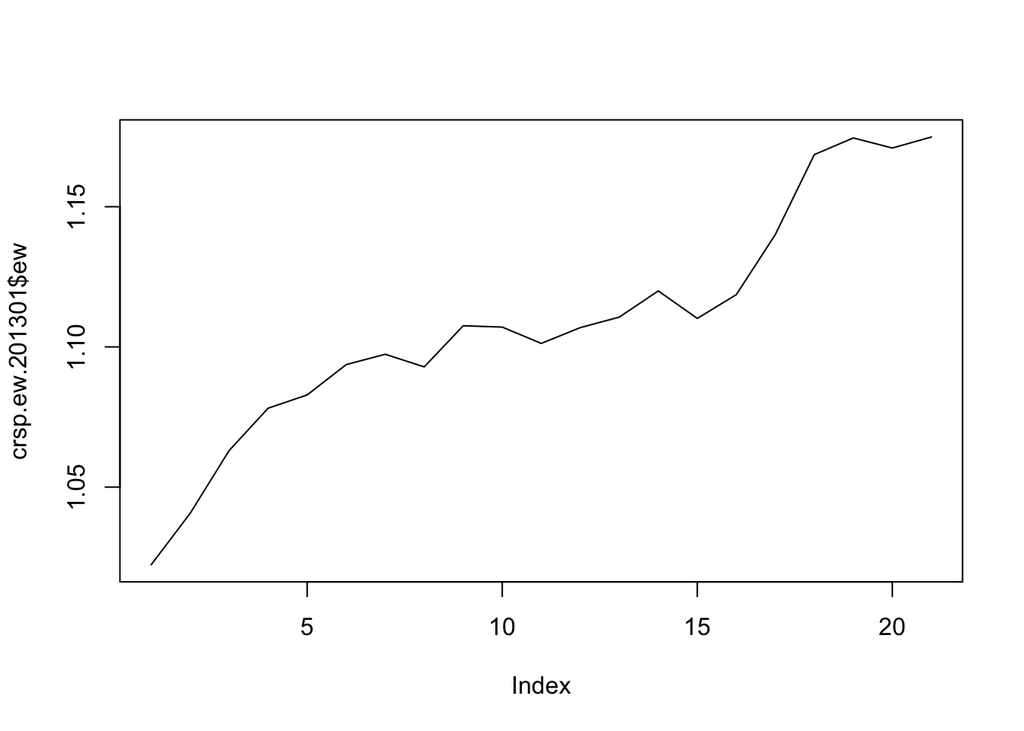

```r
crsp.ew = crsp.sample2 %>% select(permno,date,ret)
crsp.ew = spread(crsp.ew,permno,ret)
crsp.ew = gather(crsp.ew,permno,ret,-date)
crsp.ew = crsp.ew %>% group_by(permno) %>% arrange(date) %>%
  mutate(ipo=date[which(!is.na(ret))[1]]) %>% ungroup()
crsp.ew = crsp.ew %>% filter(date>=ipo) %>% arrange(permno,date)
crsp.ew = crsp.ew %>% mutate(yymm=substr(date,1,7)) %>%
  group_by(permno,yymm) %>% arrange(date) %>%
  mutate(cumret=cumprod(ret+1)) %>% ungroup()
crsp.ew = crsp.ew %>% group_by(date) %>%
  summarise(ew=mean(cumret),
            yymm=first(yymm)) %>% ungroup()
crsp.ew.201301 = crsp.ew %>% filter(yymm=='2013-01')
plot(crsp.ew.201301$ew,type='l')
```

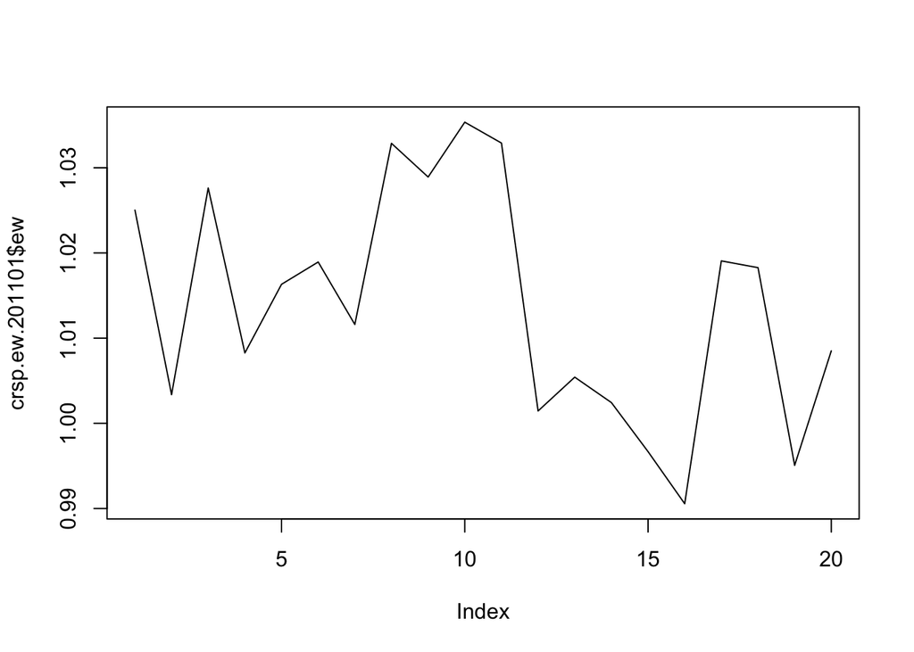

```r
crsp.ew.201101 = crsp.ew %>% filter(yymm=='2011-01')
plot(crsp.ew.201101$ew,type='l')
```